# Partner Force Training Outcome Evaluation

Nicholas Bugliari

06/28/2020

## *Summary of Data*

This file contains the following data points:

- **ID:** `int` The unique ID as a roster number for AFBiH participants.
- **entityFed:** Identifies region based on hometown. If they are from the Federation (1) or Republic (0) in `int` format.
- **male:** Identifies gender as (1) male, (0) female in `int` format.
- **univGrad:** Identifies particpant education level as (1) university graduates, (0) not graduated as an `int`.
- **agexx_xx:** `int` Dummy variables to identify age groups: **age18_25**, **age26_30**, **age31_40**, **age41plus**.
- **englishProf:** `int` Particpant’s assesment of their ability to read, write, and speak English well, (1) Strongly Disagree - (4) Strongly Agree.
- **preQx:** `int` 16 pre-test variables for PAO knowledge and PAO confidence, (1) Strongly Disagree - (4) Strongly Agree.
- **preKnow:** `int` average pre-test score for PAO knowledge construct (1) Strongly Disagree - (4) Strongly Agree..
- **preConf:** `int` average pre-test score for PAO confidence construct (1) Strongly Disagree - (4) Strongly Agree.
- **postQx:** `int` 16 posttest variables for PAO knowledge and PAO confidence, (1) Strongly Disagree - (4) Strongly Agree.
- **postKnow:** `int` average posttest score for PAO knowledge construct (1) Strongly Disagree - (4) Strongly Agree..
- **postConf:** `int` average posttest score for PAO confidence construct (1) Strongly Disagree - (4) Strongly Agree.
- **chgKnow:** `int` the % difference in PAO knowledge between from pre-test to posttest.
- **chgConf:** `int` the % difference in PAO confidence between from pre-test to posttest.
- **pctRelevant:** `int` the particpant’s post-test score from 0%-100% (20% increments) of usefulness for this training as a PAO

# **Cleaned Dataset**

Survey Data

| ï..ID | entityFed | male | univGrad | age18_25 | age26_30 | age31_40 | age41plus | englishProf | preQ1 | preQ2 | preQ3 | preQ4 | preQ5 | preQ6 | preQ7 | preQ8 | preKnow | preQ9 | preQ10 | preQ11 | preQ12 | preQ13 | preQ14 | preQ15 | preQ16 | preConf | postQ1 | postQ2 | postQ3 | … |
| --- | --- | --- | --- | --- | --- | --- | --- | --- | --- | --- | --- | --- | --- | --- | --- | --- | --- | --- | --- | --- | --- | --- | --- | --- | --- | --- | --- | --- | --- | --- |
| 2 | 1 | 0 | 1 | 0 | 1 | 0 | 0 | 3 | 3 | 2 | 2 | 2 | 3 | 2 | 3 | 2 | 2.375 | 2 | 2 | 2 | 2 | 2 | 2 | 2 | 2 | 2.000 | 4 | 4 | 4 | … |
| 3 | 1 | 0 | 1 | 0 | 1 | 0 | 0 | 3 | 3 | 3 | 3 | 3 | 4 | 2 | 4 | 3 | 3.125 | 3 | 3 | 3 | 2 | 3 | 2 | 2 | 2 | 2.500 | 4 | 4 | 3 | … |
| 4 | 1 | 1 | 1 | 0 | 0 | 0 | 1 | 2 | 3 | 3 | 3 | 3 | 3 | 3 | 3 | 3 | 3.000 | 2 | 2 | 3 | 3 | 3 | 2 | 2 | 3 | 2.500 | 4 | 4 | 4 | … |
| 5 | 1 | 1 | 1 | 0 | 0 | 0 | 1 | 1 | 4 | 3 | 3 | 3 | 3 | 3 | 3 | 3 | 3.125 | 3 | 2 | 3 | 3 | 3 | 3 | 3 | 3 | 2.875 | 4 | 3 | 3 | … |
| 6 | 1 | 1 | 1 | 0 | 0 | 0 | 1 | 2 | 3 | 3 | 3 | 3 | 3 | 3 | 3 | 3 | 3.000 | 3 | 2 | 2 | 2 | 3 | 3 | 3 | 3 | 2.625 | 4 | 4 | 3 | … |
| 7 | 1 | 1 | 1 | 0 | 0 | 0 | 1 | 2 | 3 | 3 | 3 | 3 | 4 | 3 | 3 | 4 | 3.250 | 3 | 3 | 3 | 3 | 3 | 3 | 3 | 3 | 3.000 | 3 | 3 | 3 | … |
| 8 | 1 | 1 | 1 | 0 | 0 | 0 | 1 | 3 | 3 | 3 | 3 | 4 | 3 | 3 | 4 | 3 | 3.250 | 3 | 3 | 4 | 3 | 3 | 2 | 2 | 3 | 2.875 | 3 | 3 | 3 | … |
| 9 | 1 | 1 | 1 | 0 | 0 | 0 | 1 | 2 | 4 | 3 | 4 | 3 | 3 | 3 | 3 | 3 | 3.250 | 3 | 3 | 3 | 3 | 3 | 3 | 2 | 3 | 2.875 | 4 | 3 | 4 | … |
| 12 | 0 | 1 | 1 | 0 | 0 | 0 | 1 | 4 | 2 | 2 | 2 | 2 | 2 | 2 | 2 | 2 | 2.000 | 3 | 2 | 2 | 2 | 2 | 2 | 3 | 3 | 2.375 | 3 | 2 | 2 | … |
| 13 | 0 | 1 | 1 | 0 | 0 | 0 | 1 | 4 | 3 | 2 | 3 | 3 | _ | 2 | 4 | 4 | 3.000 | 3 | 3 | 2 | 2 | 3 | 3 | 4 | 4 | 3.000 | 3 | 3 | 3 | … |
| 14 | 1 | 1 | 1 | 0 | 0 | 0 | 1 | 3 | 3 | 3 | 2 | 2 | 3 | 3 | 3 | 3 | 2.750 | 2 | 2 | 3 | 2 | 3 | 3 | 3 | 3 | 2.625 | 4 | 4 | 3 | … |
| 15 | 0 | 1 | 0 | 0 | 0 | 0 | 1 | 1 | 3 | 2 | 2 | 3 | 3 | 1 | 2 | 2 | 2.250 | 2 | 2 | 2 | 2 | 2 | 2 | 2 | 2 | 2.000 | 3 | 3 | 3 | … |
| 16 | 1 | 1 | 1 | 0 | 1 | 0 | 0 | 2 | 3 | 3 | 2 | 3 | 4 | 2 | 3 | 3 | 2.875 | 3 | 3 | 3 | 3 | 3 | 3 | 3 | 3 | 3.000 | 4 | 3 | 3 | … |
| 17 | 1 | 1 | 1 | 0 | 0 | 0 | 1 | 2 | 3 | 3 | 3 | 3 | 3 | 3 | 4 | 4 | 3.250 | 4 | 3 | 4 | 3 | 3 | 4 | 4 | 4 | 3.625 | 4 | 4 | 4 | … |
| 18 | 1 | 1 | 1 | 0 | 0 | 0 | 1 | 2 | 3 | 2 | 3 | 2 | 4 | 2 | 3 | 3 | 2.750 | 3 | 3 | 3 | 3 | 2 | 2 | 3 | 3 | 2.750 | 3 | 3 | 3 | … |
| 19 | 1 | 1 | 1 | 0 | 0 | 0 | 1 | 2 | 1 | 1 | 1 | 1 | 1 | 1 | 1 | 1 | 1.000 | 2 | 2 | 2 | 1 | 2 | 1 | 2 | 1 | 1.625 | 3 | 4 | 4 | … |
| 20 | 1 | 1 | 1 | 0 | 0 | 0 | 1 | 2 | 3 | 2 | 2 | 3 | 4 | 3 | 3 | 3 | 2.875 | 3 | 3 | 3 | 3 | 3 | 3 | 2 | 3 | 2.875 | 3 | 3 | 3 | … |

## *Determining Instrument Validity*

```r
URL_noHead <- "FinalProjectNoHead.csv"  # import dataset with header data removed
dat_noHead <- read.csv( URL_noHead, stringsAsFactors=F)

KnowPreScale <- data.frame(dat_noHead[10:17])  # create dataframe with pre-test knowledge variables

ConfPreScale <- data.frame(dat_noHead[19:26])  # create dataframe with pre-test confidence variables

KnowPostScale <- data.frame(dat_noHead[28:35])  # create dataframe with post-test knowledge variables

ConfPostScale <- data.frame(dat_noHead[37:44])  # create dataframe with post-test confidence variables

alpha(KnowPreScale) # determine cronbach's alpha of pre-test knowledge index
```

```
## Some items ( X3 ) were negatively correlated with the total scale and
## probably should be reversed.
## To do this, run the function again with the 'check.keys=TRUE' option
```

```
##
## Reliability analysis
## Call: alpha(x = KnowPreScale)
##
##   raw_alpha std.alpha G6(smc) average_r S/N   ase mean   sd median_r
##       0.85      0.86    0.92      0.44 6.4 0.056  2.7 0.52     0.59
##
##  lower alpha upper     95% confidence boundaries
## 0.74 0.85 0.96
##
##  Reliability if an item is dropped:
##      raw_alpha std.alpha G6(smc) average_r  S/N alpha se var.r med.r
## X3        0.91      0.92    0.93      0.61 10.9    0.034 0.010  0.61
## X3.1      0.82      0.83    0.88      0.41  5.0    0.070 0.091  0.54
## X2        0.81      0.83    0.89      0.41  4.8    0.071 0.105  0.56
## X2.1      0.81      0.83    0.89      0.41  4.9    0.071 0.112  0.56
## X2.2      0.81      0.83    0.90      0.42  5.0    0.070 0.110  0.59
## X3.2      0.83      0.85    0.91      0.45  5.8    0.064 0.114  0.60
## X2.3      0.82      0.84    0.90      0.43  5.3    0.067 0.117  0.61
## X3.3      0.79      0.82    0.87      0.40  4.6    0.079 0.120  0.54
##
##  Item statistics
##       n raw.r std.r r.cor r.drop mean   sd
## X3   16  0.15  0.11 0.018 -0.059  2.3 0.87
## X3.1 16  0.80  0.82 0.816  0.723  2.9 0.68
## X2   16  0.82  0.84 0.823  0.763  2.6 0.63
## X2.1 16  0.81  0.82 0.805  0.742  2.6 0.72
## X2.2 16  0.80  0.81 0.780  0.725  2.8 0.68
## X3.2 16  0.69  0.68 0.633  0.561  3.1 0.81
## X2.3 16  0.74  0.76 0.713  0.649  2.4 0.73
## X3.3 16  0.90  0.89 0.893  0.856  3.0 0.82
##
## Non missing response frequency for each item
##         1    2    3    4 miss
## X3   0.12 0.56 0.19 0.12    0
## X3.1 0.06 0.06 0.75 0.12    0
## X2   0.06 0.31 0.62 0.00    0
## X2.1 0.06 0.31 0.56 0.06    0
## X2.2 0.06 0.19 0.69 0.06    0
## X3.2 0.06 0.06 0.56 0.31    0
## X2.3 0.12 0.31 0.56 0.00    0
## X3.3 0.06 0.12 0.56 0.25    0
```

```r
alpha(ConfPreScale) # determine cronbach's alpha of pre-test confidence index
```

```
##
## Reliability analysis
## Call: alpha(x = ConfPreScale)
##
##   raw_alpha std.alpha G6(smc) average_r S/N  ase mean   sd median_r
##       0.87      0.88    0.93      0.47 7.2 0.05  2.7 0.44     0.51
##
##  lower alpha upper     95% confidence boundaries
## 0.77 0.87 0.97
##
##  Reliability if an item is dropped:
##        raw_alpha std.alpha G6(smc) average_r S/N alpha se var.r med.r
## X2.375      0.83      0.84    0.90      0.43 5.4    0.064 0.039  0.48
## X2.5        0.85      0.86    0.91      0.46 6.0    0.059 0.053  0.51
## X2.6        0.86      0.87    0.92      0.49 6.6    0.055 0.048  0.51
## X2.7        0.86      0.87    0.92      0.48 6.4    0.054 0.041  0.51
## X2.8        0.85      0.86    0.91      0.46 6.1    0.058 0.041  0.53
## X2.9        0.86      0.86    0.91      0.47 6.3    0.057 0.043  0.53
## X2.10       0.84      0.85    0.90      0.45 5.7    0.063 0.048  0.51
## X2.11       0.89      0.89    0.93      0.55 8.5    0.041 0.018  0.53
##
##  Item statistics
##         n raw.r std.r r.cor r.drop mean   sd
## X2.375 16  0.87  0.88  0.88   0.82  2.8 0.60
## X2.5   16  0.79  0.79  0.76   0.72  2.8 0.54
## X2.6   16  0.67  0.70  0.64   0.58  2.6 0.51
## X2.7   16  0.71  0.72  0.68   0.60  2.8 0.66
## X2.8   16  0.77  0.77  0.75   0.68  2.5 0.63
## X2.9   16  0.72  0.73  0.72   0.64  2.8 0.45
## X2.10  16  0.84  0.82  0.81   0.76  2.6 0.73
## X2.11  16  0.51  0.47  0.42   0.34  2.7 0.70
##
## Non missing response frequency for each item
##           1    2 2.25 2.75 2.875    3 3.125 3.25    4 miss
## X2.375 0.06 0.06 0.06 0.12  0.12 0.19  0.12 0.25 0.00    0
## X2.5   0.00 0.25 0.00 0.00  0.00 0.69  0.00 0.00 0.06    0
## X2.6   0.00 0.44 0.00 0.00  0.00 0.56  0.00 0.00 0.00    0
## X2.7   0.00 0.31 0.00 0.00  0.00 0.56  0.00 0.00 0.12    0
## X2.8   0.06 0.38 0.00 0.00  0.00 0.56  0.00 0.00 0.00    0
## X2.9   0.00 0.25 0.00 0.00  0.00 0.75  0.00 0.00 0.00    0
## X2.10  0.06 0.38 0.00 0.00  0.00 0.50  0.00 0.00 0.06    0
## X2.11  0.00 0.44 0.00 0.00  0.00 0.44  0.00 0.00 0.12    0
```

```r
alpha(KnowPostScale) # determine cronbach's alpha of pre-test knowledge index
```

```
##
## Reliability analysis
## Call: alpha(x = KnowPostScale)
##
##   raw_alpha std.alpha G6(smc) average_r S/N  ase mean   sd median_r
##        0.8       0.8    0.86      0.33 3.9 0.07  3.3 0.35     0.35
##
##  lower alpha upper     95% confidence boundaries
## 0.67 0.8 0.94
##
##  Reliability if an item is dropped:
##       raw_alpha std.alpha G6(smc) average_r S/N alpha se var.r med.r
## X2.13      0.83      0.83    0.87      0.41 4.9    0.061 0.045  0.42
## X4         0.78      0.77    0.84      0.32 3.4    0.077 0.080  0.34
## X4.1       0.77      0.76    0.82      0.31 3.1    0.085 0.062  0.31
## X4.2       0.74      0.73    0.80      0.28 2.8    0.094 0.058  0.31
## X4.3       0.76      0.75    0.82      0.30 3.0    0.088 0.052  0.31
## X4.4       0.82      0.81    0.86      0.38 4.2    0.065 0.071  0.42
## X3.4       0.76      0.75    0.82      0.30 3.0    0.088 0.061  0.31
## X4.5       0.77      0.76    0.82      0.31 3.2    0.082 0.065  0.34
##
##  Item statistics
##        n raw.r std.r r.cor r.drop mean   sd
## X2.13 16  0.25  0.29  0.18  0.094  2.7 0.45
## X4    16  0.65  0.65  0.58  0.518  3.5 0.52
## X4.1  16  0.73  0.72  0.69  0.608  3.3 0.60
## X4.2  16  0.84  0.82  0.82  0.760  3.2 0.54
## X4.3  16  0.78  0.76  0.75  0.685  3.4 0.51
## X4.4  16  0.40  0.44  0.34  0.245  3.7 0.48
## X3.4  16  0.78  0.74  0.73  0.645  3.2 0.68
## X4.5  16  0.70  0.70  0.66  0.585  3.6 0.50
##
## Non missing response frequency for each item
##       1.625    2 2.375  2.5 2.625 2.75 2.875    3 3.625    4 miss
## X2.13  0.06 0.06  0.06 0.12  0.12 0.06  0.25 0.19  0.06 0.00    0
## X4     0.00 0.00  0.00 0.00  0.00 0.00  0.00 0.50  0.00 0.50    0
## X4.1   0.00 0.06  0.00 0.00  0.00 0.00  0.00 0.56  0.00 0.38    0
## X4.2   0.00 0.06  0.00 0.00  0.00 0.00  0.00 0.69  0.00 0.25    0
## X4.3   0.00 0.00  0.00 0.00  0.00 0.00  0.00 0.56  0.00 0.44    0
## X4.4   0.00 0.00  0.00 0.00  0.00 0.00  0.00 0.31  0.00 0.69    0
## X3.4   0.00 0.12  0.00 0.00  0.00 0.00  0.00 0.50  0.00 0.38    0
## X4.5   0.00 0.00  0.00 0.00  0.00 0.00  0.00 0.38  0.00 0.62    0
```

```r
alpha(ConfPostScale) # determine cronbach's alpha of pre-test confidence index
```

```
## In factor.stats, I could not find the RMSEA upper bound . Sorry about that
```

```
## In smc, smcs < 0 were set to .0
```

```
## In smc, smcs < 0 were set to .0
```

```
## In smc, smcs < 0 were set to .0
```

```
##
## Reliability analysis
## Call: alpha(x = ConfPostScale)
##
##   raw_alpha std.alpha G6(smc) average_r S/N   ase mean   sd median_r
##       0.83      0.83    0.86      0.38   5 0.063  3.2 0.29     0.38
##
##  lower alpha upper     95% confidence boundaries
## 0.7 0.83 0.95
##
##  Reliability if an item is dropped:
##       raw_alpha std.alpha G6(smc) average_r S/N alpha se var.r med.r
## X3.75      0.78      0.79    0.81      0.35 3.8    0.079 0.089  0.35
## X3.6       0.80      0.80    0.89      0.37 4.1    0.070 0.061  0.41
## X4.6       0.85      0.87    0.88      0.48 6.5    0.057 0.054  0.46
## X3.7       0.80      0.80    0.80      0.36 4.0    0.076 0.090  0.41
## X3.8       0.82      0.83    0.83      0.41 4.9    0.068 0.079  0.35
## X4.7       0.80      0.81    0.83      0.38 4.2    0.070 0.089  0.35
## X3.9       0.78      0.78    0.80      0.34 3.6    0.078 0.073  0.32
## X3.10      0.80      0.80    0.89      0.37 4.1    0.070 0.061  0.41
##
##  Item statistics
##        n raw.r std.r r.cor r.drop mean   sd
## X3.75 16  0.81  0.79  0.80   0.75  3.4 0.39
## X3.6  16  0.69  0.74  0.62   0.60  3.1 0.34
## X4.6  16  0.28  0.29  0.15   0.13  3.0 0.37
## X3.7  16  0.79  0.75  0.76   0.65  3.4 0.63
## X3.8  16  0.62  0.57  0.55   0.48  2.9 0.44
## X4.7  16  0.71  0.71  0.68   0.57  3.4 0.50
## X3.9  16  0.81  0.84  0.86   0.74  3.2 0.40
## X3.10 16  0.69  0.74  0.62   0.60  3.1 0.34
##
## Non missing response frequency for each item
##          2 2.625    3 3.125 3.25  3.5 3.625 3.75 3.875    4 miss
## X3.75 0.00  0.06 0.06  0.12 0.25 0.12  0.06 0.12  0.06 0.12    0
## X3.6  0.00  0.00 0.88  0.00 0.00 0.00  0.00 0.00  0.00 0.12    0
## X4.6  0.06  0.00 0.88  0.00 0.00 0.00  0.00 0.00  0.00 0.06    0
## X3.7  0.06  0.00 0.44  0.00 0.00 0.00  0.00 0.00  0.00 0.50    0
## X3.8  0.12  0.00 0.81  0.00 0.00 0.00  0.00 0.00  0.00 0.06    0
## X4.7  0.00  0.00 0.62  0.00 0.00 0.00  0.00 0.00  0.00 0.38    0
## X3.9  0.00  0.00 0.81  0.00 0.00 0.00  0.00 0.00  0.00 0.19    0
## X3.10 0.00  0.00 0.88  0.00 0.00 0.00  0.00 0.00  0.00 0.12    0
```

## *Average Gain in PAO Knowledge & Confidence*

```r
pctChng <- subset( dat, ID = 2:20, select = c( "chngKnow", "chngConf" ))  # subset the data for just %change

stargazer( pctChng, type = "text" )  # statistical summary for %change in knowledge and confidence
```

```
##
## ===========================================================
## Statistic N   Mean  St. Dev.  Min  Pctl(25) Pctl(75)  Max
## -----------------------------------------------------------
## chngKnow  17 16.912  15.588  0.000  6.250    18.750  65.625
## chngConf  17 13.419  11.200  0.000  6.250    18.750  37.500
## -----------------------------------------------------------
```

```r
# create variables for average change in knowledge and confidence based on table above

avg.chngKnow <- 16.912
avg.chngConf <- 13.419
avg.pctChng <- data.frame( avg.chngKnow, avg.chngConf )
```

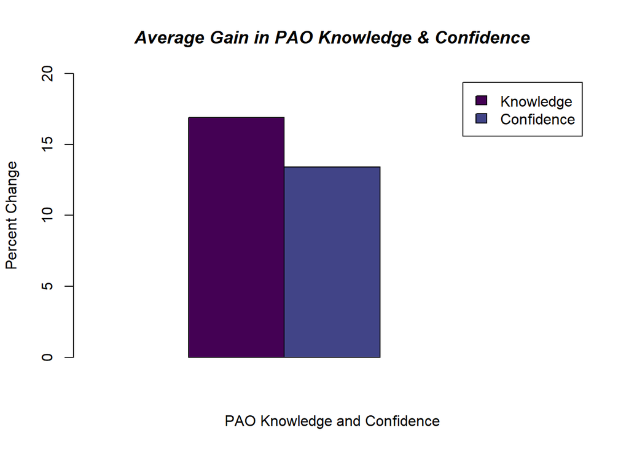

```r
barplot(t(as.matrix(avg.pctChng)),
        beside = TRUE,
        col = viridis(6),
        legend.text = c( "Knowledge", "Confidence" ),
        ylim = c(0,20),
        xlim = c(0,5),
        ylab = "Percent Change",
        xlab = "PAO Knowledge and Confidence")
title(main = list("Average Gain in PAO Knowledge & Confidence", font = 4))
```

## *Gain in PAO Knowledge & Confidence: By Entity*

```r
# Filter for Republic

rsFilter <- filter( dat, entityFed == 0 )

# Subset for % Change variables

rsChng <- subset( rsFilter, select = c( "chngKnow", "chngConf" ))  # subset the data for just %change


stargazer( rsChng, type = "text" )  # statistical summary for %change in knowledge and confidence
```

```
##
## ==========================================================
## Statistic N  Mean  St. Dev.  Min  Pctl(25) Pctl(75)  Max
## ----------------------------------------------------------
## chngKnow  3 15.625  9.375   6.250  10.938   20.312  25.000
## chngConf  3 11.458  12.630  0.000  4.688    17.188  25.000
## ----------------------------------------------------------
```

```r
# create variables for average change in knowledge and confidence based on table above

avg.rschngKnow <- 15.625
avg.rschngConf <- 11.458
```

```r
# Filter for Federation

fbFilter <- filter( dat, entityFed == 1 )

# Subset for % Change variables

fbChng <- subset( fbFilter, select = c( "chngKnow", "chngConf" ))  # subset the data for just %change


stargazer( fbChng, type = "text" )  # statistical summary for %change in knowledge and confidence
```

```
##
## ===========================================================
## Statistic N   Mean  St. Dev.  Min  Pctl(25) Pctl(75)  Max
## -----------------------------------------------------------
## chngKnow  14 17.188  16.884  0.000  7.031    18.750  65.625
## chngConf  14 13.839  11.348  0.000  6.250    18.750  37.500
## -----------------------------------------------------------
```

```r
# create variables for average change in knowledge and confidence based on table above

avg.fbchngKnow <- 17.188
avg.fbchngConf <- 13.839
avg.entitypctChng <- data.frame( avg.fbchngKnow, avg.fbchngConf, avg.rschngKnow, avg.rschngConf )
```

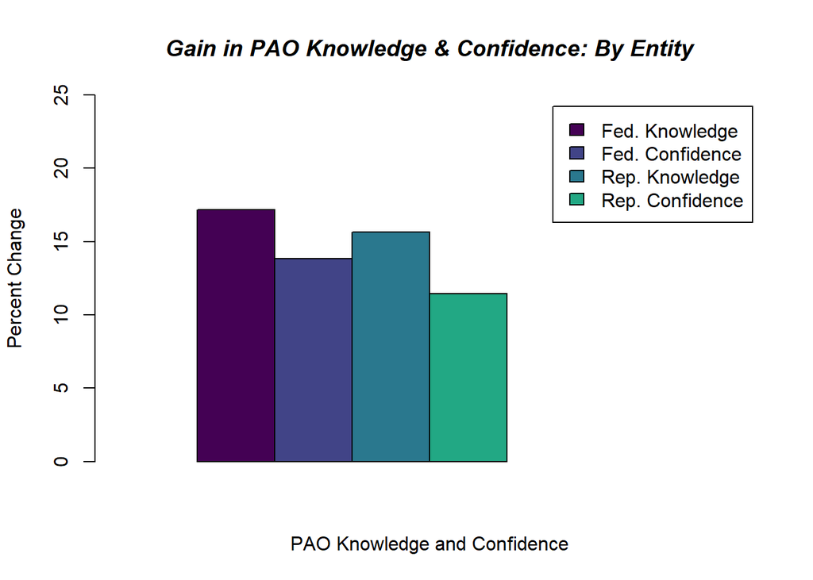

```r
barplot(t(as.matrix(avg.entitypctChng)),
        beside = TRUE,
        col = viridis(6),
        legend.text = c( "Fed. Knowledge", "Fed. Confidence", "Rep. Knowledge", "Rep. Confidence" ),
        ylim = c(0,25),
        xlim = c(0,8),
        ylab = "Percent Change",
        xlab = "PAO Knowledge and Confidence")
title(main = list("Gain in PAO Knowledge & Confidence: By Entity", font = 4))
```

## *Gain in PAO Knowledge & Confidence: Age 18-30 vs. Overall*

```r
# Filter for Age 18-30

age30Filter <- filter( dat, age18_25 == 1 | age26_30 == 1 )

# Subset for % Change variables

age30Chng <- subset( age30Filter, select = c( "chngKnow", "chngConf" ))  # subset the data for just %change


stargazer( age30Chng, type = "text" )  # statistical summary for %change in knowledge and confidence
```

```
##
## ===========================================================
## Statistic N  Mean  St. Dev.  Min   Pctl(25) Pctl(75)  Max
## -----------------------------------------------------------
## chngKnow  3 21.875  10.825  15.625  15.625   25.000  34.375
## chngConf  3 23.958  6.505   18.750  20.312   26.562  31.250
## -----------------------------------------------------------
```

```r
# create variables for average change in knowledge and confidence based on table above

avg.age30chngKnow <- 21.875
avg.age30chngConf <- 23.958
avg.age30pctChng <- data.frame( avg.age30chngKnow, avg.age30chngConf, avg.chngKnow, avg.chngConf )
```

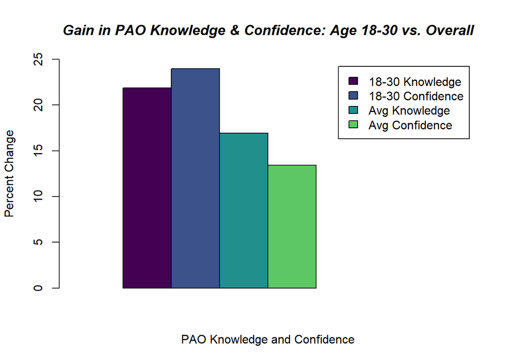

```r
barplot(t(as.matrix(avg.age30pctChng)),
        beside = TRUE,
        col = viridis(5),
        legend.text = c( "18-30 Knowledge", "18-30 Confidence", "Avg Knowledge", "Avg Confidence" ),
        ylim = c(0,25),
        xlim = c(0,8),
        ylab = "Percent Change",
        xlab = "PAO Knowledge and Confidence")
title(main = list("Gain in PAO Knowledge & Confidence: Age 18-30 vs. Overall", font = 4))
```

## *Gain in PAO Knowledge & Confidence: Age 31+ vs. Overall*

```r
# Filter for Age 31+

age31Filter <- filter( dat, age31_40 == 1 | age41plus == 1 )

# Subset for % Change variables

age31Chng <- subset( age31Filter, select = c( "chngKnow", "chngConf" ))  # subset the data for just %change


stargazer( age31Chng, type = "text" )  # statistical summary for %change in knowledge and confidence
```

```
##
## ===========================================================
## Statistic N   Mean  St. Dev.  Min  Pctl(25) Pctl(75)  Max
## -----------------------------------------------------------
## chngKnow  14 15.848  16.557    0     6.2      18.8     66
## chngConf  14 11.161  10.805  0.000  3.906    17.188  37.500
## -----------------------------------------------------------
```

```r
# create variables for average change in knowledge and confidence based on table above

avg.age31chngKnow <- 15.848
avg.age31chngConf <- 11.161
avg.age31pctChng <- data.frame( avg.age31chngKnow, avg.age31chngConf, avg.chngKnow, avg.chngConf )
```

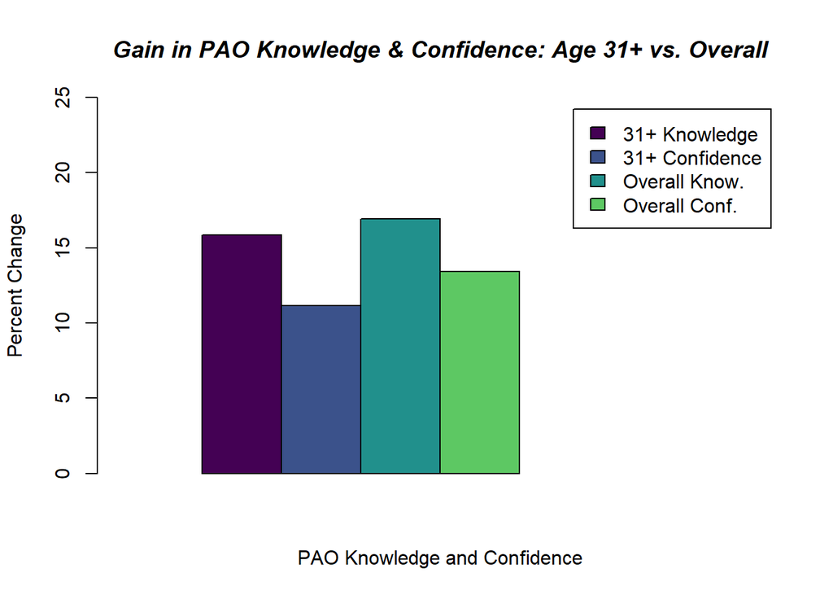

```r
barplot(t(as.matrix(avg.age31pctChng)),
        beside = TRUE,
        col = viridis(5),
        legend.text = c( "31+ Knowledge", "31+ Confidence", "Overall Know.", "Overall Conf." ),
        ylim = c(0,25),
        xlim = c(0,8),
        ylab = "Percent Change",
        xlab = "PAO Knowledge and Confidence")
title(main = list("Gain in PAO Knowledge & Confidence: Age 31+ vs. Overall", font = 4))
```